# Daniel Minaya

En esta tarea van a crear una red neuronal que clasifique mensajes como spam o no spam. Lo primero es descargar la data:

Los datos vienen en un archivo CSV que contiene dos columnas "text" y "label". La columna "text" contiene el texto del mensaje y la columna "label" contiene las etiquetas "ham" y "spam". Un mensaje "ham" es un mensaje que no se considera spam.

# Tarea

El objetivo de la tarea es crear una red neuronal que clasifique los datos entregados. Para lograr esto debes:

- Implementar el pre-procesamiento de los datos que creas necesario.
- Particionar los datos en 70% entrenamiento, 10% validación y 20% test.
- Usa los datos de entrenamiento y valiadación para tus experimentos y sólo usa el conjunto de test para reportar el resultado final.

Para el diseño de la red neuronal puedes usar una red neuronal recurrente o una red basada en transformers. El objetivo de la tarea no es obtener el performance ultra máximo, sino entender qué decisiones de diseño afectan la solución de un problema como este. Lo que si es necesario (como siempre) es que discutas los resultados y decisiones realizadas.

## Librerías

```python
import pandas as pd
import numpy as np
from string import punctuation
from collections import Counter
import torch
import torch.nn as nn
from torch.utils.data import TensorDataset, DataLoader
import matplotlib.pyplot as plt
import copy
from IPython.display import display, Markdown
```

## Pre-procesamiento

### Carga del dataset

```python
df = pd.read_csv('spam.csv')

# Separamos en texts, labels
texts = df['text'].values
labels = df['label'].values
```

### Datos con etiquetas malas

```python
not_labels_index = []

# Buscamos etiquetas que no sean ham o spam
for i, label in enumerate(labels):
    if label not in ['ham', 'spam']:
        not_labels_index.append(i)
```

```python
len(not_labels_index), len(labels)
```

```
(209, 5572)
```

Podemos ver que hay etiquetas que no corresponden a las válidas: ham o spam, así que eliminaremos los datos con estas etiquetas ya que solo eliminaremos 209 filas de un total de 5572.

```python
# Eliminamos las filas con labels incorrectos
df = df.drop(index=not_labels_index)

# Redefinimos los texts y labels
texts = df['text'].values
labels = df['label'].values
```

### Formateo del texto

Pasamos todo los textos a minúsculas y eliminamos los signos de puntuación.

```python
# Pasamos los elementos a tipo texto
texts = texts.astype(str)

# Pasamos a minúscula
texts = np.char.lower(texts)

# Removemos signos de puntuación
remove_punctuation = lambda text: ''.join([char for char in text if char not in punctuation])
remove_punctuation_array = np.vectorize(remove_punctuation)
texts = remove_punctuation_array(texts)
```

### Codificación de las palabras

```python
# Obtenemos todas las palabras
words = ' '.join(texts)
words = words.split()

# Contamos las apariciones de las palabras
counts = Counter(words)

# Obtenemos el vocabulario ordenando por frecuencia
vocab = sorted(counts, key=counts.get, reverse=True)

# Obtenemos diccionario word to index
vocab_to_int = {word: ii for ii, word in enumerate(vocab, 1)}

#Ahora convertimos cada palabra de los textos en índices
texts_int = []
for review in texts:
    texts_int.append([vocab_to_int[word] for word in review.split()])
```

```python
#Cada texto ahora se representa como una secuencia de números (índices)
print(texts[0])
print(texts_int[0])
```

```
go until jurong point crazy available only in bugis n great world la e buffet cine there got amore wat
[45, 437, 4221, 775, 693, 731, 64, 8, 1201, 89, 121, 364, 1202, 146, 2808, 1203, 68, 55, 4222, 134]
```

```python
#Cuántas palabras hay en el diccionario?
print('Palabras únicas:', len(vocab_to_int))
```

```
Palabras únicas: 9196
```

### Embedding de labels

Las etiquetas se convierten a números para poder ser ingresadas a la red neuronal.

```python
# Codificamos spam como 1
encoded_labels = np.array([1 if label == 'spam' else 0 for label in labels])

labels, encoded_labels
```

```
(array(['ham', 'ham', 'spam', ..., 'ham', 'ham', 'ham'], dtype=object),
 array([0, 0, 1, ..., 0, 0, 0]))
```

### Longitud de secuencias

```python
#Sacamos algunas estadísticas de los datos
text_lens = Counter([len(x) for x in texts_int])
print("Reviews de longitud cero:", text_lens[0])
print('Máxima longitud:', max(text_lens))
```

```
Reviews de longitud cero: 2
Máxima longitud: 171
```

```python
print('Datos antes de eliminación:', len(texts_int))

#Extraemos los índices de todos los textos que tienen longitud > 0
non_zero_idx = [ii for ii, review in enumerate(texts_int) if len(review)!=0]

#Nos quedamos solo con los textos con longitud > 0
texts_int = [texts_int[ii] for ii in non_zero_idx]

#Lo mismo con los labels
encoded_labels = np.array([encoded_labels[ii] for ii in non_zero_idx])

print('Datos después de eliminación:', len(texts_int))
```

```
Datos antes de eliminación: 5363
Datos después de eliminación: 5361
```

### Padding

```python
def pad_features(texts_int, seq_length):
    features = np.zeros((len(texts_int), seq_length), dtype=int)

    #Para cada texto, se coloca en la matriz
    for i, row in enumerate(texts_int):
        features[i, -len(row):] = np.array(row)[:seq_length]

    return features

#Definimos seq_length como la máxima longitud
seq_length = 171

features = pad_features(texts_int, seq_length=seq_length)

print(features.shape)
print(features[30:,-10:])
```

```
(5361, 171)
[[  19  139  160 ...  268   33  197]
 [  38  232   45 ... 4250 1111    3]
 [   0    0    0 ...  174   79    3]
 ...
 [   0 9193   59 ... 9194  225 9195]
 [ 214  112    7 ...  197   12   46]
 [   0    0    0 ...    1   42  263]]
```

## Creación de Datasets

### Partición de los datos

```python
def split_data(features):
    # Separamos 70% para entrenamiento
    split_idx = int(len(features)*0.7)
    train_x, remaining_x = features[:split_idx], features[split_idx:]
    train_y, remaining_y = encoded_labels[:split_idx], encoded_labels[split_idx:]

    # Del 30% restante separamos 33% para validación y el resto para prueba
    test_idx = int(len(remaining_x)*(1/3))
    val_x, test_x = remaining_x[:test_idx], remaining_x[test_idx:]
    val_y, test_y = remaining_y[:test_idx], remaining_y[test_idx:]

    # Reportamos el tamaño de los conjuntos
    print("\t\t\tFeatures:")
    print("Train set: \t\t{}".format(train_x.shape),
          "\nValidation set: \t{}".format(val_x.shape),
          "\nTest set: \t\t{}\n".format(test_x.shape))

    return train_x, val_x, test_x, train_y, val_y, test_y

train_x, val_x, test_x, train_y, val_y, test_y = split_data(features)
```

```
			Features:
Train set: 		(3752, 171)
Validation set: 	(536, 171)
Test set: 		(1073, 171)
```

### Datasets

```python
def toTensorDataset(train_x, val_x, test_x, train_y, val_y, test_y):
    # Creamos los TensorDataset
    train_data = TensorDataset(torch.from_numpy(train_x), torch.from_numpy(train_y))
    val_data = TensorDataset(torch.from_numpy(val_x), torch.from_numpy(val_y))
    test_data = TensorDataset(torch.from_numpy(test_x), torch.from_numpy(test_y))

    return train_data, val_data, test_data

train_data, val_data, test_data = toTensorDataset(train_x, val_x, test_x, train_y, val_y, test_y)
```

### DataLoader

```python
def toDataLoader(train_data, val_data, test_data, batch_size, seed):
    torch.manual_seed(seed)

    # Creamos los DataLoader
    train_loader = DataLoader(train_data, shuffle=True, batch_size=batch_size)
    val_loader = DataLoader(val_data, shuffle=True, batch_size=batch_size)
    test_loader = DataLoader(test_data, shuffle=False, batch_size=batch_size)

    return train_loader, val_loader, test_loader

train_loader, val_loader, test_loader = toDataLoader(train_data, val_data, test_data, 50, 42)
```

## Creación de la red

```python
# Chequear si tenemos GPU
train_on_gpu=torch.cuda.is_available()

if(train_on_gpu):
    print('Training on GPU.')
else:
    print('No GPU available, training on CPU.')
```

```
Training on GPU.
```

### Clase RNN

Definimos la RNN como una red que tendrá un capa de embeddings que transforme los tokens de palabras en embeddings de una dimensión fija (embedding_dim), luego una capa LSTM que procese la secuencia de entrada. Después este resultado se pasa por una capa lineal fully-connected que transforme el resultado de la LSTM a la dimensión de salida, que en nuestro caso será 1, y por último pasamos este resultado por una sigmoide para llevar el resultado al intervalo $(0,1)$, donde se define el umbral $0.5$, donde los scores menores a 0.5 serán etiquetados como ham y los mayores a 0.5 serán etiquetas como spam.

```python
#Creamos la red neuronal
class RNN(nn.Module):
    def __init__(self, vocab_size, output_size, embedding_dim, hidden_dim, n_layers, drop_prob=0.5):
        super(RNN, self).__init__()

        self.output_size = output_size
        self.n_layers = n_layers
        self.hidden_dim = hidden_dim

        # Capas embedding y LSTM
        self.embedding = nn.Embedding(vocab_size, embedding_dim)
        self.lstm = nn.LSTM(embedding_dim, hidden_dim, n_layers,
                            dropout=drop_prob, batch_first=True)

        # dropout
        self.dropout = nn.Dropout(drop_prob)

        # Capa lineal y sigmoide
        self.fc = nn.Linear(hidden_dim, output_size)
        self.sig = nn.Sigmoid()

    def forward(self, x, hidden):
        embeds = self.embedding(x)
        lstm_out, hidden = self.lstm(embeds, hidden)

        #Tomamos solo el último valor de salida del LSTM
        lstm_out = lstm_out[:,-1,:]

        # dropout y fully-connected
        out = self.dropout(lstm_out)
        out = self.fc(out)

        # sigmoide
        sig_out = self.sig(out)

        # retornar sigmoide y último estado oculto
        return sig_out, hidden


    def init_hidden(self, batch_size):
        # Crea dos nuevos tensores con tamaño n_layers x batch_size x hidden_dim,
        # inicializados a cero, para estado oculto y memoria de LSTM
        weight = next(self.parameters()).data

        if(train_on_gpu):
            hidden = (weight.new(self.n_layers, batch_size, self.hidden_dim).zero_().cuda(),
                      weight.new(self.n_layers, batch_size, self.hidden_dim).zero_().cuda())
        else:
            hidden = (weight.new(self.n_layers, batch_size, self.hidden_dim).zero_(),
                      weight.new(self.n_layers, batch_size, self.hidden_dim).zero_())

        return hidden
```

### Funciones de entrenamiento y evaluación

```python
# Función que calcula el número de predicciones correctas
def count_corrects(pred, labels):
    # Obtenemos el vector de igualdades (1 si la predicción es correcta, 0 si no)
    correct_tensor = pred.eq(labels.float().view_as(pred))
    correct = np.squeeze(correct_tensor.numpy()) if not train_on_gpu else np.squeeze(correct_tensor.cpu().numpy())

    # Sumamos la cantidad de predicciones correctas
    return np.sum(correct)
```

```python
# Función que toma el modelo y un dataset y lo entrena
def train(model, loader, optimizer, clip):
    losses = []
    num_correct = 0

    # Ponemos el modelo en entrenamiento
    model.train()

    for inputs, labels in loader:
        # Inicializar estado oculto
        h = model.init_hidden(len(inputs))

        if(train_on_gpu):
            inputs, labels = inputs.cuda(), labels.cuda()

        # Crear nuevas variables para estados ocultos, sino se haría
        # backprop para todos los pasos del bucle
        h = tuple([each.data for each in h])

        model.zero_grad()

        # Hacer pasada forward
        output, h = model(inputs, h)

        # Calcular loss y hacer backprop
        loss = criterion(output.squeeze(), labels.float())
        losses.append(loss.item())

        loss.backward()

        # gradient clipping
        nn.utils.clip_grad_norm_(model.parameters(), clip)
        optimizer.step()

        with torch.no_grad():
            pred = torch.round(output.squeeze())

            # Comparar predicciones a labels
            num_correct += count_corrects(pred, labels)

    loss = np.mean(losses)
    accuracy = num_correct/len(loader.dataset)

    return loss, accuracy
```

```python
# Función que toma el modelo y un dataset y entrega la función de pérdida y accuracy
def evaluate(model, loader):
    losses = []
    num_correct = 0

    # Ponemos el modelo en evaluación
    model.eval()

    for inputs, labels in loader:
        # Iniciamos estado oculto
        h = model.init_hidden(len(inputs))

        h = tuple([each.data for each in h])

        if(train_on_gpu):
            inputs, labels = inputs.cuda(), labels.cuda()

        output, h = model(inputs, h)

        loss = criterion(output.squeeze(), labels.float())
        losses.append(loss.item())

        # Convertir probabilidades a clases (0,1)
        pred = torch.round(output.squeeze())

        # Comparar predicciones a labels
        num_correct += count_corrects(pred, labels)

    loss = np.mean(losses)
    accuracy = num_correct / len(loader.dataset)

    return loss, accuracy
```

### Función principal

```python
# Función que ejecuta todo lo anterior
def main(seq_length, batch_size, embedding_dim, hidden_dim, n_layers, epochs, criterion, lr, clip, seed):
    torch.manual_seed(seed)

    # Truncamos los textos tokenizados
    features = pad_features(texts_int, seq_length=seq_length)

    # Separamos la data en train, val y test
    train_x, val_x, test_x, train_y, val_y, test_y = split_data(features)

    # Pasamos a Dataset y Dataloader
    train_data, val_data, test_data = toTensorDataset(train_x, val_x, test_x, train_y, val_y, test_y)
    train_loader, val_loader, test_loader = toDataLoader(train_data, val_data, test_data, batch_size, seed)

    # Atributos para la red
    vocab_size = len(vocab_to_int) + 1
    output_size = 1

    # Instanciamos la red
    net = RNN(vocab_size, output_size, embedding_dim, hidden_dim, n_layers)

    # Definimos el optimizador
    optimizer = torch.optim.Adam(net.parameters(), lr=lr)

    # Enviar red al GPU
    if(train_on_gpu):
        net.cuda()

    best_model_wts = copy.deepcopy(net.state_dict())
    best_accuracy = 0.0

    # Listas para guardar loss y accuracy por epoca
    train_accuracy_list, val_accuracy_list, train_loss_list, val_loss_list = [], [], [], []

    net.train()

    # Bucle de entrenamiento
    for e in range(epochs):
        # Entrenamos
        train_loss, train_accuracy = train(net, train_loader, optimizer, clip)

        # Validamos al final de cada época
        val_loss, val_accuracy = evaluate(net, val_loader)

        # Guardamos el mejor modelo
        if val_accuracy > best_accuracy:
            best_accuracy = val_accuracy
            best_model_wts = copy.deepcopy(net.state_dict())

        print(f"Epoch: {e+1}/{epochs}\n",
              f"\tTrain loss: {train_loss:.6f}\n",
              f"\tTrain accuracy: {train_accuracy:.6f}\n",
              f"\tVal loss: {val_loss:.6f}\n",
              f"\tVal accuracy: {val_accuracy:.6f}\n",
             )

        train_accuracy_list.append(train_accuracy)
        val_accuracy_list.append(val_accuracy)
        train_loss_list.append(train_loss)
        val_loss_list.append(val_loss)

    # Cargamos el mejor modelo
    net.load_state_dict(best_model_wts)

    # Evaluamos
    test_loss, test_accuracy = evaluate(net, test_loader)

    print("Test loss: {:.3f}".format(test_loss))
    print("Test accuracy: {:.3f}".format(test_accuracy))

    return train_accuracy_list, val_accuracy_list, train_loss_list, val_loss_list, test_loss, test_accuracy
```

### Función para plotear

```python
# Función que plotea los accuracy y loss
def plot_results(train_accuracy_list, val_accuracy_list, train_loss_list, val_loss_list):
    epochs = len(train_accuracy_list)

    # Plot accuracy
    plt.figure(figsize=(12, 5))
    plt.subplot(1, 2, 1)
    plt.plot(range(1, epochs+1), train_accuracy_list, label='Training Accuracy')
    plt.plot(range(1, epochs+1), val_accuracy_list, label='Validation Accuracy')
    plt.xlabel('Epoch')
    plt.ylabel('Accuracy')
    plt.legend()
    plt.title('Training and Validation Accuracy')

    # Plot loss
    plt.subplot(1, 2, 2)
    plt.plot(range(1, epochs+1), train_loss_list, label='Training Loss')
    plt.plot(range(1, epochs+1), val_loss_list, label='Validation Loss')
    plt.xlabel('Epoch')
    plt.ylabel('Loss')
    plt.legend()
    plt.title('Training and Validation Loss')

    plt.tight_layout()
    plt.show()
```

## Experimentos

```python
# Atributos fijos
criterion = nn.BCELoss()
lr = 0.001
clip = 5
seed = 42
```

### Cambiando la longitud de las palabras (seq_length)

Largo de secuencia: 10

```
			Features:
Train set: 		(3752, 10)
Validation set: 	(536, 10)
Test set: 		(1073, 10)

Epoch: 1/10
 	Train loss: 0.236804
 	Train accuracy: 0.913913
 	Val loss: 0.147336
 	Val accuracy: 0.940299

Epoch: 2/10
 	Train loss: 0.088025
 	Train accuracy: 0.977345
 	Val loss: 0.149353
 	Val accuracy: 0.958955

Epoch: 3/10
 	Train loss: 0.046401
 	Train accuracy: 0.987473
 	Val loss: 0.176186
 	Val accuracy: 0.957090

Epoch: 4/10
 	Train loss: 0.019429
 	Train accuracy: 0.996002
 	Val loss: 0.273478
 	Val accuracy: 0.949627

Epoch: 5/10
 	Train loss: 0.020769
 	Train accuracy: 0.993603
 	Val loss: 0.174345
 	Val accuracy: 0.955224

Epoch: 6/10
 	Train loss: 0.010046
 	Train accuracy: 0.997068
 	Val loss: 0.156842
 	Val accuracy: 0.958955
```

[output cut: 12 more lines]

```

Epoch: 9/10
 	Train loss: 0.000253
 	Train accuracy: 1.000000
 	Val loss: 0.249343
 	Val accuracy: 0.953358

Epoch: 10/10
 	Train loss: 0.000129
 	Train accuracy: 1.000000
 	Val loss: 0.260091
 	Val accuracy: 0.951493

Test loss: 0.165
Test accuracy: 0.972
```

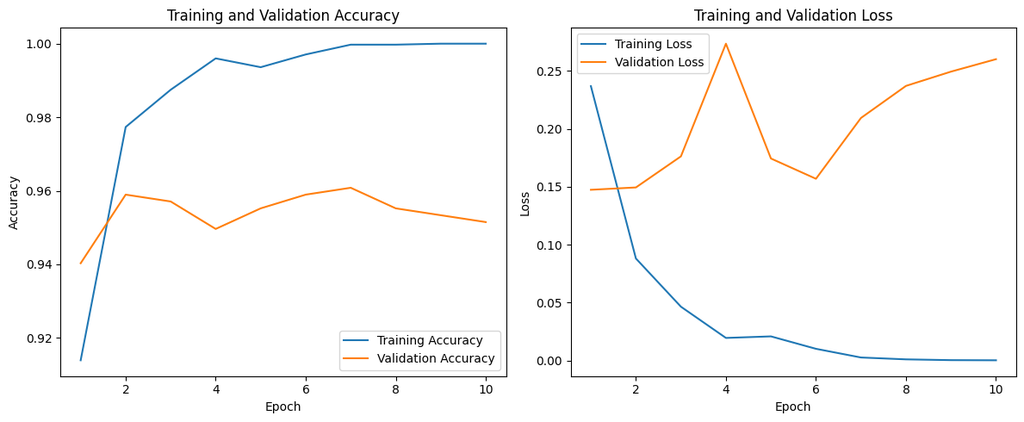

Largo de secuencia: 100

```
			Features:
Train set: 		(3752, 100)
Validation set: 	(536, 100)
Test set: 		(1073, 100)

Epoch: 1/10
 	Train loss: 0.183024
 	Train accuracy: 0.935768
 	Val loss: 0.094167
 	Val accuracy: 0.966418

Epoch: 2/10
 	Train loss: 0.053851
 	Train accuracy: 0.984542
 	Val loss: 0.082689
 	Val accuracy: 0.975746

Epoch: 3/10
 	Train loss: 0.023906
 	Train accuracy: 0.993603
 	Val loss: 0.107212
 	Val accuracy: 0.968284

Epoch: 4/10
 	Train loss: 0.008348
 	Train accuracy: 0.997868
 	Val loss: 0.107202
 	Val accuracy: 0.975746

Epoch: 5/10
 	Train loss: 0.001156
 	Train accuracy: 0.999467
 	Val loss: 0.110785
 	Val accuracy: 0.975746

Epoch: 6/10
 	Train loss: 0.000297
 	Train accuracy: 1.000000
 	Val loss: 0.116341
 	Val accuracy: 0.975746
```

[output cut: 12 more lines]

```

Epoch: 9/10
 	Train loss: 0.000073
 	Train accuracy: 1.000000
 	Val loss: 0.131012
 	Val accuracy: 0.975746

Epoch: 10/10
 	Train loss: 0.000056
 	Train accuracy: 1.000000
 	Val loss: 0.135290
 	Val accuracy: 0.975746

Test loss: 0.079
Test accuracy: 0.980
```

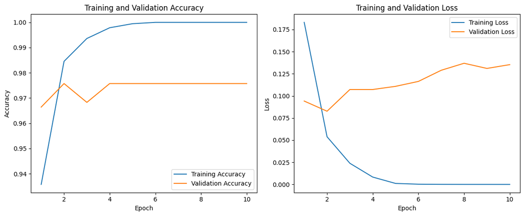

Largo de secuencia: 200

```
			Features:
Train set: 		(3752, 200)
Validation set: 	(536, 200)
Test set: 		(1073, 200)

Epoch: 1/10
 	Train loss: 0.182348
 	Train accuracy: 0.936301
 	Val loss: 0.094217
 	Val accuracy: 0.964552

Epoch: 2/10
 	Train loss: 0.055077
 	Train accuracy: 0.984009
 	Val loss: 0.067829
 	Val accuracy: 0.977612

Epoch: 3/10
 	Train loss: 0.025679
 	Train accuracy: 0.993337
 	Val loss: 0.084511
 	Val accuracy: 0.981343

Epoch: 4/10
 	Train loss: 0.007918
 	Train accuracy: 0.997868
 	Val loss: 0.087904
 	Val accuracy: 0.977612

Epoch: 5/10
 	Train loss: 0.002002
 	Train accuracy: 0.999467
 	Val loss: 0.099513
 	Val accuracy: 0.981343

Epoch: 6/10
 	Train loss: 0.000299
 	Train accuracy: 1.000000
 	Val loss: 0.096570
 	Val accuracy: 0.981343
```

[output cut: 12 more lines]

```

Epoch: 9/10
 	Train loss: 0.000071
 	Train accuracy: 1.000000
 	Val loss: 0.118272
 	Val accuracy: 0.981343

Epoch: 10/10
 	Train loss: 0.000044
 	Train accuracy: 1.000000
 	Val loss: 0.121733
 	Val accuracy: 0.981343

Test loss: 0.095
Test accuracy: 0.979
```

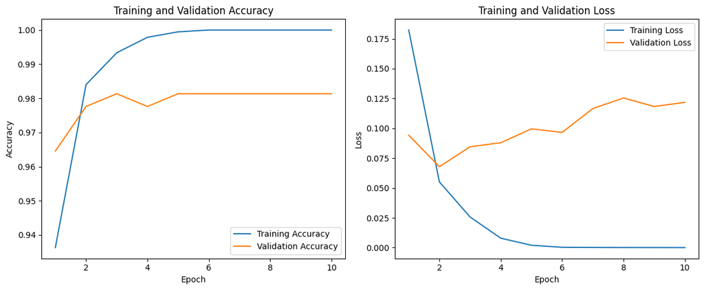

```python
seq_lengths = [10, 100, 200]
batch_size = 50
embedding_dim = 400
hidden_dim = 256
n_layers = 2
epochs = 10

test_accuracy_list = []

for seq_length in seq_lengths:
    display(Markdown(f"##Largo de secuencia: {seq_length}"))

    train_accuracy_list, val_accuracy_list, train_loss_list, val_loss_list, test_loss, test_accuracy = main(
        seq_length=seq_length,
        batch_size=batch_size,
        embedding_dim=embedding_dim,
        hidden_dim=hidden_dim,
        n_layers=n_layers,
        epochs=epochs,
        criterion=criterion,
        lr=lr,
        clip=clip,
        seed=seed,
    )

    test_accuracy_list.append(test_accuracy)

    plot_results(train_accuracy_list, val_accuracy_list, train_loss_list, val_loss_list)
```

```python
pd.DataFrame({'seq_length': seq_lengths, 'test_accuracy': test_accuracy_list})
```

|  | seq_length | test_accuracy |
| --- | --- | --- |
| 0 | 10 | 0.972041 |
| 1 | 100 | 0.980429 |
| 2 | 200 | 0.979497 |

En este caso, podemos ver que aumentar seq_length aumenta ligeramente el accuracy en el conjunto de prueba, sin embargo, aumentarlo demasiado lo empeora, esto se debe a que al entregarle mayor información al modelo, es decir, evitar truncar demasiado las frases le entregamos un mayor contexto al modelo, por lo que puede aprender de mejor manera. Por otro lado, aumentar demasiado el límite hace que la mayoría de las oraciones tengan mucho padding, es decir, hayan muchos ceros, lo que podría entorpecer el aprendizaje.

Aún así, podemos ver que para nuestro dataset la variación en el desempeño es bastante ligera.

### Cambiando tamaño del batch

Tamaño del batch: 10

```
			Features:
Train set: 		(3752, 200)
Validation set: 	(536, 200)
Test set: 		(1073, 200)

Epoch: 1/10
 	Train loss: 0.150768
 	Train accuracy: 0.949893
 	Val loss: 0.089180
 	Val accuracy: 0.973881

Epoch: 2/10
 	Train loss: 0.053797
 	Train accuracy: 0.985341
 	Val loss: 0.093432
 	Val accuracy: 0.962687

Epoch: 3/10
 	Train loss: 0.017449
 	Train accuracy: 0.994403
 	Val loss: 0.094475
 	Val accuracy: 0.977612

Epoch: 4/10
 	Train loss: 0.003834
 	Train accuracy: 0.999200
 	Val loss: 0.067566
 	Val accuracy: 0.981343

Epoch: 5/10
 	Train loss: 0.000698
 	Train accuracy: 1.000000
 	Val loss: 0.094534
 	Val accuracy: 0.981343

Epoch: 6/10
 	Train loss: 0.000172
 	Train accuracy: 1.000000
 	Val loss: 0.100378
 	Val accuracy: 0.979478
```

[output cut: 12 more lines]

```

Epoch: 9/10
 	Train loss: 0.000040
 	Train accuracy: 1.000000
 	Val loss: 0.121463
 	Val accuracy: 0.981343

Epoch: 10/10
 	Train loss: 0.000027
 	Train accuracy: 1.000000
 	Val loss: 0.128438
 	Val accuracy: 0.981343

Test loss: 0.081
Test accuracy: 0.983
```

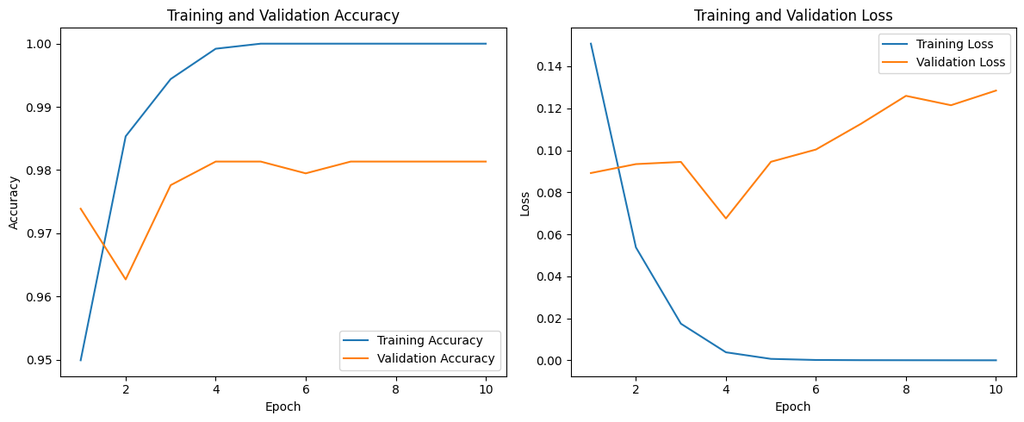

Tamaño del batch: 100

```
			Features:
Train set: 		(3752, 200)
Validation set: 	(536, 200)
Test set: 		(1073, 200)

Epoch: 1/10
 	Train loss: 0.230924
 	Train accuracy: 0.917111
 	Val loss: 0.110042
 	Val accuracy: 0.964552

Epoch: 2/10
 	Train loss: 0.070089
 	Train accuracy: 0.980810
 	Val loss: 0.084725
 	Val accuracy: 0.973881

Epoch: 3/10
 	Train loss: 0.041079
 	Train accuracy: 0.990938
 	Val loss: 0.074498
 	Val accuracy: 0.973881

Epoch: 4/10
 	Train loss: 0.020868
 	Train accuracy: 0.994403
 	Val loss: 0.058334
 	Val accuracy: 0.981343

Epoch: 5/10
 	Train loss: 0.008135
 	Train accuracy: 0.997601
 	Val loss: 0.064942
 	Val accuracy: 0.979478

Epoch: 6/10
 	Train loss: 0.002684
 	Train accuracy: 0.999467
 	Val loss: 0.075309
 	Val accuracy: 0.977612
```

[output cut: 12 more lines]

```

Epoch: 9/10
 	Train loss: 0.001128
 	Train accuracy: 0.999733
 	Val loss: 0.080512
 	Val accuracy: 0.979478

Epoch: 10/10
 	Train loss: 0.007504
 	Train accuracy: 0.998401
 	Val loss: 0.082525
 	Val accuracy: 0.975746

Test loss: 0.085
Test accuracy: 0.979
```

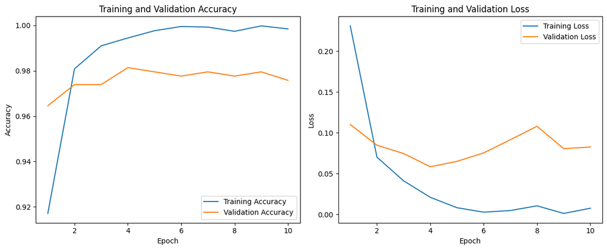

Tamaño del batch: 1000

```
			Features:
Train set: 		(3752, 200)
Validation set: 	(536, 200)
Test set: 		(1073, 200)

Epoch: 1/10
 	Train loss: 0.614784
 	Train accuracy: 0.761727
 	Val loss: 0.403349
 	Val accuracy: 0.843284

Epoch: 2/10
 	Train loss: 0.325875
 	Train accuracy: 0.862207
 	Val loss: 0.310071
 	Val accuracy: 0.845149

Epoch: 3/10
 	Train loss: 0.220725
 	Train accuracy: 0.897122
 	Val loss: 0.230205
 	Val accuracy: 0.934701

Epoch: 4/10
 	Train loss: 0.181974
 	Train accuracy: 0.955757
 	Val loss: 0.188575
 	Val accuracy: 0.938433

Epoch: 5/10
 	Train loss: 0.138688
 	Train accuracy: 0.962953
 	Val loss: 0.174087
 	Val accuracy: 0.944030

Epoch: 6/10
 	Train loss: 0.113858
 	Train accuracy: 0.970949
 	Val loss: 0.129253
 	Val accuracy: 0.960821
```

[output cut: 12 more lines]

```

Epoch: 9/10
 	Train loss: 0.051097
 	Train accuracy: 0.986940
 	Val loss: 0.077390
 	Val accuracy: 0.973881

Epoch: 10/10
 	Train loss: 0.041399
 	Train accuracy: 0.989606
 	Val loss: 0.075104
 	Val accuracy: 0.975746

Test loss: 0.088
Test accuracy: 0.977
```

```python
seq_lengths = 171
batch_sizes = [10, 100, 1000]
embedding_dim = 400
hidden_dim = 256
n_layers = 2
epochs = 10

test_accuracy_list = []

for batch_size in batch_sizes:
    display(Markdown(f"##Tamaño del batch: {batch_size}"))

    train_accuracy_list, val_accuracy_list, train_loss_list, val_loss_list, test_loss, test_accuracy = main(
        seq_length=seq_length,
        batch_size=batch_size,
        embedding_dim=embedding_dim,
        hidden_dim=hidden_dim,
        n_layers=n_layers,
        epochs=epochs,
        criterion=criterion,
        lr=lr,
        clip=clip,
        seed=seed,
    )

    test_accuracy_list.append(test_accuracy)

    plot_results(train_accuracy_list, val_accuracy_list, train_loss_list, val_loss_list)
```

[output not shown]

```python
pd.DataFrame({'batch_size': batch_sizes, 'test_accuracy': test_accuracy_list})
```

|  | batch_size | test_accuracy |
| --- | --- | --- |
| 0 | 10 | 0.983225 |
| 1 | 100 | 0.979497 |
| 2 | 1000 | 0.976701 |

En este caso podemos ver que aumentar el tamaño del batch empeora el desempeño del modelo en el conjunto de prueba, lo cual podría indicar que nuestro modelo necesita de la aleatoriedad de los mini-batches para alcanzar un mejor desempeño, es decir, la función de costo es muy compleja o tiene muchos mínimos locales, por lo que utilizar batches más pequeños nos permiten salir de estos mínimos y lograr llegar a un mínimo global o al menos a un mejor mínimo.

Aún así, la variación del accuracy en el conjunto de prueba no es tan significativa.

### Cambiando la dimensión de los embeddings

Dimensión de embedding: 10

```
			Features:
Train set: 		(3752, 200)
Validation set: 	(536, 200)
Test set: 		(1073, 200)

Epoch: 1/10
 	Train loss: 0.672789
 	Train accuracy: 0.625800
 	Val loss: 0.582591
 	Val accuracy: 0.843284

Epoch: 2/10
 	Train loss: 0.448881
 	Train accuracy: 0.862207
 	Val loss: 0.467740
 	Val accuracy: 0.843284

Epoch: 3/10
 	Train loss: 0.351635
 	Train accuracy: 0.862207
 	Val loss: 0.370686
 	Val accuracy: 0.843284

Epoch: 4/10
 	Train loss: 0.336215
 	Train accuracy: 0.862207
 	Val loss: 0.328800
 	Val accuracy: 0.843284

Epoch: 5/10
 	Train loss: 0.295281
 	Train accuracy: 0.862207
 	Val loss: 0.323764
 	Val accuracy: 0.843284

Epoch: 6/10
 	Train loss: 0.276591
 	Train accuracy: 0.866738
 	Val loss: 0.304585
 	Val accuracy: 0.861940
```

[output cut: 12 more lines]

```

Epoch: 9/10
 	Train loss: 0.233742
 	Train accuracy: 0.904584
 	Val loss: 0.265427
 	Val accuracy: 0.893657

Epoch: 10/10
 	Train loss: 0.220958
 	Train accuracy: 0.915512
 	Val loss: 0.261738
 	Val accuracy: 0.899254

Test loss: 0.179
Test accuracy: 0.926
```

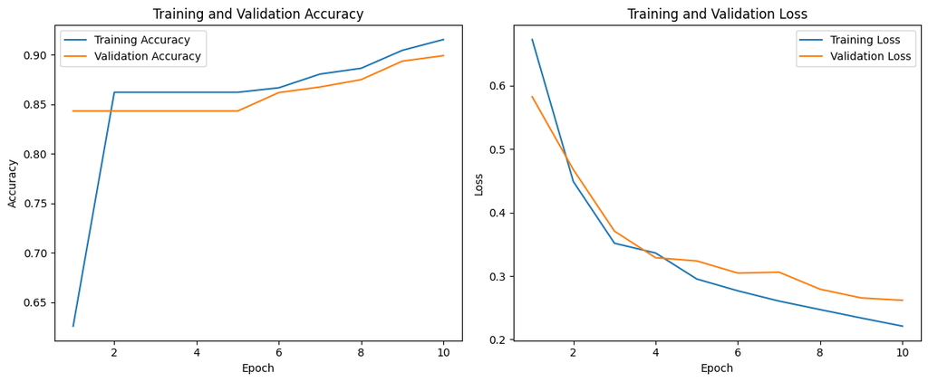

Dimensión de embedding: 50

```
			Features:
Train set: 		(3752, 200)
Validation set: 	(536, 200)
Test set: 		(1073, 200)

Epoch: 1/10
 	Train loss: 0.620638
 	Train accuracy: 0.859542
 	Val loss: 0.494683
 	Val accuracy: 0.843284

Epoch: 2/10
 	Train loss: 0.392173
 	Train accuracy: 0.862207
 	Val loss: 0.415333
 	Val accuracy: 0.843284

Epoch: 3/10
 	Train loss: 0.327919
 	Train accuracy: 0.862207
 	Val loss: 0.350839
 	Val accuracy: 0.843284

Epoch: 4/10
 	Train loss: 0.301760
 	Train accuracy: 0.862473
 	Val loss: 0.316540
 	Val accuracy: 0.843284

Epoch: 5/10
 	Train loss: 0.273302
 	Train accuracy: 0.862740
 	Val loss: 0.308201
 	Val accuracy: 0.848881

Epoch: 6/10
 	Train loss: 0.248551
 	Train accuracy: 0.882729
 	Val loss: 0.287321
 	Val accuracy: 0.884328
```

[output cut: 12 more lines]

```

Epoch: 9/10
 	Train loss: 0.183883
 	Train accuracy: 0.938699
 	Val loss: 0.236929
 	Val accuracy: 0.910448

Epoch: 10/10
 	Train loss: 0.160284
 	Train accuracy: 0.943497
 	Val loss: 0.228024
 	Val accuracy: 0.916045

Test loss: 0.120
Test accuracy: 0.949
```

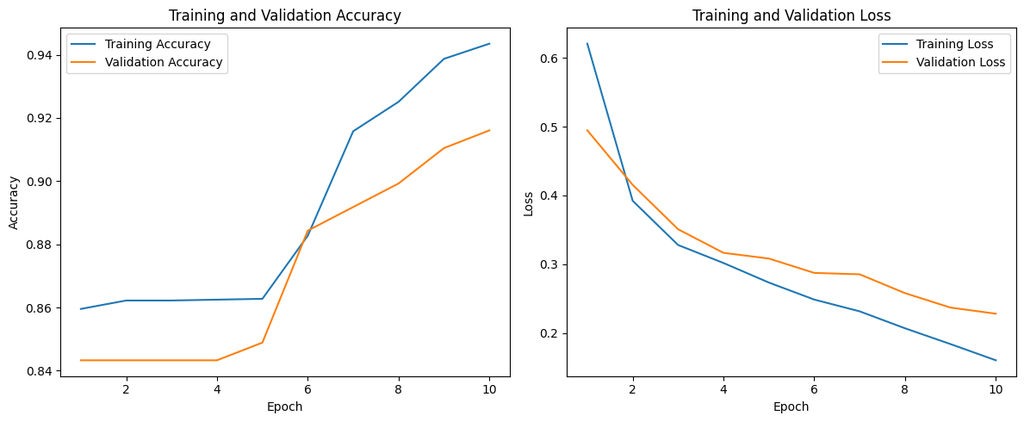

Dimensión de embedding: 400

```
			Features:
Train set: 		(3752, 200)
Validation set: 	(536, 200)
Test set: 		(1073, 200)

Epoch: 1/10
 	Train loss: 0.614784
 	Train accuracy: 0.761727
 	Val loss: 0.403349
 	Val accuracy: 0.843284

Epoch: 2/10
 	Train loss: 0.325875
 	Train accuracy: 0.862207
 	Val loss: 0.310071
 	Val accuracy: 0.845149

Epoch: 3/10
 	Train loss: 0.220725
 	Train accuracy: 0.897122
 	Val loss: 0.230205
 	Val accuracy: 0.934701

Epoch: 4/10
 	Train loss: 0.181974
 	Train accuracy: 0.955757
 	Val loss: 0.188575
 	Val accuracy: 0.938433

Epoch: 5/10
 	Train loss: 0.138688
 	Train accuracy: 0.962953
 	Val loss: 0.174087
 	Val accuracy: 0.944030

Epoch: 6/10
 	Train loss: 0.113858
 	Train accuracy: 0.970949
 	Val loss: 0.129253
 	Val accuracy: 0.960821
```

[output cut: 12 more lines]

```

Epoch: 9/10
 	Train loss: 0.051097
 	Train accuracy: 0.986940
 	Val loss: 0.077390
 	Val accuracy: 0.973881

Epoch: 10/10
 	Train loss: 0.041399
 	Train accuracy: 0.989606
 	Val loss: 0.075104
 	Val accuracy: 0.975746

Test loss: 0.088
Test accuracy: 0.977
```

```python
seq_lengths = 171
batch_sizes = 50
embedding_dims = [10, 50, 400]
hidden_dim = 256
n_layers = 2
epochs = 10

test_accuracy_list = []

for embedding_dim in embedding_dims:
    display(Markdown(f"##Dimensión de embedding: {embedding_dim}"))

    train_accuracy_list, val_accuracy_list, train_loss_list, val_loss_list, test_loss, test_accuracy = main(
        seq_length=seq_length,
        batch_size=batch_size,
        embedding_dim=embedding_dim,
        hidden_dim=hidden_dim,
        n_layers=n_layers,
        epochs=epochs,
        criterion=criterion,
        lr=lr,
        clip=clip,
        seed=seed,
    )

    test_accuracy_list.append(test_accuracy)

    plot_results(train_accuracy_list, val_accuracy_list, train_loss_list, val_loss_list)
```

[output not shown]

```python
pd.DataFrame({'embedding_dim': embedding_dims, 'test_accuracy': test_accuracy_list})
```

|  | embedding_dim | test_accuracy |
| --- | --- | --- |
| 0 | 10 | 0.926375 |
| 1 | 50 | 0.948742 |
| 2 | 400 | 0.976701 |

En este caso podemos ver que aumentar la dimensión de los embeddings mejora notablemente el desempeño del modelo en el conjunto de prueba. Esto se explica a que tener una mayor dimensión para representar las palabras nos permite capturar mayor información semántica entre las palabras, sin embargo, aumentar demasiado esta dimensión podría llevar a sobreajuste.

Para nuestro dataset podemos ver que este hiperparámetro es bastante significativo para el desempeño del modelo.

### Cambiando la dimensión del estado oculto

```
			Features:
Train set: 		(3752, 200)
Validation set: 	(536, 200)
Test set: 		(1073, 200)

Epoch: 1/10
 	Train loss: 0.647483
 	Train accuracy: 0.829158
 	Val loss: 0.635858
 	Val accuracy: 0.843284

Epoch: 2/10
 	Train loss: 0.629841
 	Train accuracy: 0.850480
 	Val loss: 0.618674
 	Val accuracy: 0.843284

Epoch: 3/10
 	Train loss: 0.612338
 	Train accuracy: 0.861141
 	Val loss: 0.601093
 	Val accuracy: 0.843284

Epoch: 4/10
 	Train loss: 0.594262
 	Train accuracy: 0.863006
 	Val loss: 0.582541
 	Val accuracy: 0.843284

Epoch: 5/10
 	Train loss: 0.574457
 	Train accuracy: 0.863006
 	Val loss: 0.562798
 	Val accuracy: 0.843284

Epoch: 6/10
 	Train loss: 0.554775
 	Train accuracy: 0.862207
 	Val loss: 0.541735
 	Val accuracy: 0.843284
```

[output cut: 12 more lines]

```

Epoch: 9/10
 	Train loss: 0.486041
 	Train accuracy: 0.862740
 	Val loss: 0.470416
 	Val accuracy: 0.843284

Epoch: 10/10
 	Train loss: 0.457099
 	Train accuracy: 0.863006
 	Val loss: 0.444106
 	Val accuracy: 0.843284

Test loss: 0.630
Test accuracy: 0.865
```

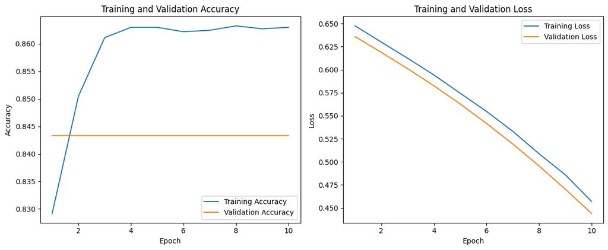

```
			Features:
Train set: 		(3752, 200)
Validation set: 	(536, 200)
Test set: 		(1073, 200)

Epoch: 1/10
 	Train loss: 0.714069
 	Train accuracy: 0.280117
 	Val loss: 0.679605
 	Val accuracy: 0.710821

Epoch: 2/10
 	Train loss: 0.654930
 	Train accuracy: 0.759328
 	Val loss: 0.608063
 	Val accuracy: 0.854478

Epoch: 3/10
 	Train loss: 0.566012
 	Train accuracy: 0.868070
 	Val loss: 0.491635
 	Val accuracy: 0.845149

Epoch: 4/10
 	Train loss: 0.432105
 	Train accuracy: 0.865938
 	Val loss: 0.361984
 	Val accuracy: 0.843284

Epoch: 5/10
 	Train loss: 0.318862
 	Train accuracy: 0.862473
 	Val loss: 0.334716
 	Val accuracy: 0.843284

Epoch: 6/10
 	Train loss: 0.285404
 	Train accuracy: 0.862207
 	Val loss: 0.313378
 	Val accuracy: 0.848881
```

[output cut: 12 more lines]

```

Epoch: 9/10
 	Train loss: 0.175417
 	Train accuracy: 0.955224
 	Val loss: 0.208388
 	Val accuracy: 0.936567

Epoch: 10/10
 	Train loss: 0.160383
 	Train accuracy: 0.966684
 	Val loss: 0.195916
 	Val accuracy: 0.942164

Test loss: 0.152
Test accuracy: 0.959
```

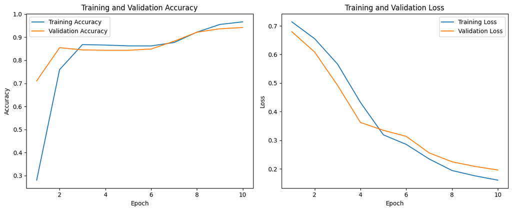

```
			Features:
Train set: 		(3752, 200)
Validation set: 	(536, 200)
Test set: 		(1073, 200)

Epoch: 1/10
 	Train loss: 0.614784
 	Train accuracy: 0.761727
 	Val loss: 0.403349
 	Val accuracy: 0.843284

Epoch: 2/10
 	Train loss: 0.325875
 	Train accuracy: 0.862207
 	Val loss: 0.310071
 	Val accuracy: 0.845149

Epoch: 3/10
 	Train loss: 0.220725
 	Train accuracy: 0.897122
 	Val loss: 0.230205
 	Val accuracy: 0.934701

Epoch: 4/10
 	Train loss: 0.181974
 	Train accuracy: 0.955757
 	Val loss: 0.188575
 	Val accuracy: 0.938433

Epoch: 5/10
 	Train loss: 0.138688
 	Train accuracy: 0.962953
 	Val loss: 0.174087
 	Val accuracy: 0.944030

Epoch: 6/10
 	Train loss: 0.113858
 	Train accuracy: 0.970949
 	Val loss: 0.129253
 	Val accuracy: 0.960821
```

[output cut: 12 more lines]

```

Epoch: 9/10
 	Train loss: 0.051097
 	Train accuracy: 0.986940
 	Val loss: 0.077390
 	Val accuracy: 0.973881

Epoch: 10/10
 	Train loss: 0.041399
 	Train accuracy: 0.989606
 	Val loss: 0.075104
 	Val accuracy: 0.975746

Test loss: 0.088
Test accuracy: 0.977
```

```python
seq_lengths = 171
batch_sizes = 50
embedding_dim = 400
hidden_dims = [16, 64, 256]
n_layers = 2
epochs = 10

test_accuracy_list = []

for hidden_dim in hidden_dims:
    display(Markdown(f"##Dimensión de embedding: {hidden_dim}"))

    train_accuracy_list, val_accuracy_list, train_loss_list, val_loss_list, test_loss, test_accuracy = main(
        seq_length=seq_length,
        batch_size=batch_size,
        embedding_dim=embedding_dim,
        hidden_dim=hidden_dim,
        n_layers=n_layers,
        epochs=epochs,
        criterion=criterion,
        lr=lr,
        clip=clip,
        seed=seed,
    )

    test_accuracy_list.append(test_accuracy)

    plot_results(train_accuracy_list, val_accuracy_list, train_loss_list, val_loss_list)
```

[output not shown]

```python
pd.DataFrame({'hidden_dim': hidden_dims, 'test_accuracy': test_accuracy_list})
```

|  | hidden_dim | test_accuracy |
| --- | --- | --- |
| 0 | 16 | 0.864865 |
| 1 | 64 | 0.958993 |
| 2 | 256 | 0.976701 |

En este caso, vemos que el modelo mejora notablemente el accuracy en el conjunto de prueba al aumentar la dimensión del estado oculto. Esto se explica de manera similar a lo anterior, aumentar la dimensión nos permite capturar patrones más complejos en los datos, pero se corre el mismo riesgo de sobreajuste aumentar de manera excesiva este parámetro.

Para nuestro dataset, este hiperparámetro es de gran relevancia para obtener un buen desempeño en el modelo.

### Cambiando el número de capas de la LSTM

Número de capas: 2

```
			Features:
Train set: 		(3752, 200)
Validation set: 	(536, 200)
Test set: 		(1073, 200)

Epoch: 1/10
 	Train loss: 0.614784
 	Train accuracy: 0.761727
 	Val loss: 0.403349
 	Val accuracy: 0.843284

Epoch: 2/10
 	Train loss: 0.325875
 	Train accuracy: 0.862207
 	Val loss: 0.310071
 	Val accuracy: 0.845149

Epoch: 3/10
 	Train loss: 0.220725
 	Train accuracy: 0.897122
 	Val loss: 0.230205
 	Val accuracy: 0.934701

Epoch: 4/10
 	Train loss: 0.181974
 	Train accuracy: 0.955757
 	Val loss: 0.188575
 	Val accuracy: 0.938433

Epoch: 5/10
 	Train loss: 0.138688
 	Train accuracy: 0.962953
 	Val loss: 0.174087
 	Val accuracy: 0.944030

Epoch: 6/10
 	Train loss: 0.113858
 	Train accuracy: 0.970949
 	Val loss: 0.129253
 	Val accuracy: 0.960821
```

[output cut: 12 more lines]

```

Epoch: 9/10
 	Train loss: 0.051097
 	Train accuracy: 0.986940
 	Val loss: 0.077390
 	Val accuracy: 0.973881

Epoch: 10/10
 	Train loss: 0.041399
 	Train accuracy: 0.989606
 	Val loss: 0.075104
 	Val accuracy: 0.975746

Test loss: 0.088
Test accuracy: 0.977
```

Número de capas: 4

```
			Features:
Train set: 		(3752, 200)
Validation set: 	(536, 200)
Test set: 		(1073, 200)

Epoch: 1/10
 	Train loss: 0.607130
 	Train accuracy: 0.860608
 	Val loss: 0.364653
 	Val accuracy: 0.843284

Epoch: 2/10
 	Train loss: 0.339616
 	Train accuracy: 0.862207
 	Val loss: 0.292481
 	Val accuracy: 0.843284

Epoch: 3/10
 	Train loss: 0.256477
 	Train accuracy: 0.880864
 	Val loss: 0.232554
 	Val accuracy: 0.916045

Epoch: 4/10
 	Train loss: 0.180631
 	Train accuracy: 0.949627
 	Val loss: 0.201785
 	Val accuracy: 0.940299

Epoch: 5/10
 	Train loss: 0.140192
 	Train accuracy: 0.962687
 	Val loss: 0.148352
 	Val accuracy: 0.938433

Epoch: 6/10
 	Train loss: 0.099057
 	Train accuracy: 0.971748
 	Val loss: 0.103749
 	Val accuracy: 0.968284
```

[output cut: 12 more lines]

```

Epoch: 9/10
 	Train loss: 0.048830
 	Train accuracy: 0.990139
 	Val loss: 0.075235
 	Val accuracy: 0.981343

Epoch: 10/10
 	Train loss: 0.037669
 	Train accuracy: 0.992271
 	Val loss: 0.079634
 	Val accuracy: 0.977612

Test loss: 0.085
Test accuracy: 0.978
```

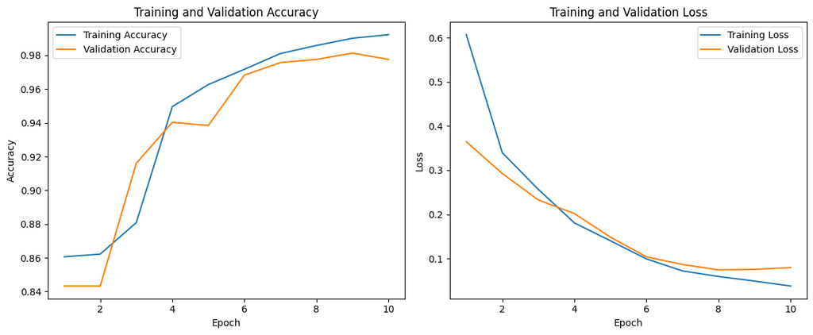

Número de capas: 6

```
			Features:
Train set: 		(3752, 200)
Validation set: 	(536, 200)
Test set: 		(1073, 200)

Epoch: 1/10
 	Train loss: 0.603355
 	Train accuracy: 0.862207
 	Val loss: 0.382936
 	Val accuracy: 0.843284

Epoch: 2/10
 	Train loss: 0.379791
 	Train accuracy: 0.862207
 	Val loss: 0.350196
 	Val accuracy: 0.843284

Epoch: 3/10
 	Train loss: 0.319494
 	Train accuracy: 0.862207
 	Val loss: 0.283082
 	Val accuracy: 0.843284

Epoch: 4/10
 	Train loss: 0.219509
 	Train accuracy: 0.905384
 	Val loss: 0.216345
 	Val accuracy: 0.932836

Epoch: 5/10
 	Train loss: 0.154288
 	Train accuracy: 0.952026
 	Val loss: 0.167698
 	Val accuracy: 0.942164

Epoch: 6/10
 	Train loss: 0.110232
 	Train accuracy: 0.968017
 	Val loss: 0.103965
 	Val accuracy: 0.972015
```

[output cut: 12 more lines]

```

Epoch: 9/10
 	Train loss: 0.060158
 	Train accuracy: 0.986141
 	Val loss: 0.081933
 	Val accuracy: 0.979478

Epoch: 10/10
 	Train loss: 0.057031
 	Train accuracy: 0.986940
 	Val loss: 0.079875
 	Val accuracy: 0.981343

Test loss: 0.091
Test accuracy: 0.974
```

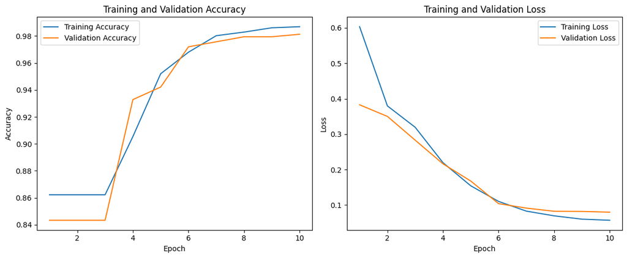

```python
seq_lengths = 171
batch_sizes = 50
embedding_dim = 400
hidden_dims = 256
n_layers_list = [2, 4, 6]
epochs = 10

test_accuracy_list = []

for n_layers in n_layers_list:
    display(Markdown(f"##Número de capas: {n_layers}"))

    train_accuracy_list, val_accuracy_list, train_loss_list, val_loss_list, test_loss, test_accuracy = main(
        seq_length=seq_length,
        batch_size=batch_size,
        embedding_dim=embedding_dim,
        hidden_dim=hidden_dim,
        n_layers=n_layers,
        epochs=epochs,
        criterion=criterion,
        lr=lr,
        clip=clip,
        seed=seed,
    )

    test_accuracy_list.append(test_accuracy)

    plot_results(train_accuracy_list, val_accuracy_list, train_loss_list, val_loss_list)
```

[output not shown]

```python
pd.DataFrame({'n_layers': n_layers_list, 'test_accuracy': test_accuracy_list})
```

|  | n_layers | test_accuracy |
| --- | --- | --- |
| 0 | 2 | 0.976701 |
| 1 | 4 | 0.977633 |
| 2 | 6 | 0.973905 |

En este caso podemos ver que aumentar el número de capas de la LSTM de 2 a 4 mejora el accuracy en el conjunto de prueba, sin embargo, aumentar a 6 capas lo empeora. El número de capas le entrega una mayor complejidad al modelo para aprender patrones más complejos, pero también aumenta la duración del entrenamiento y eleva el riesgo de sobreajuste. Para nuestro dataset, considerar 4 capas para la LSTM es adecuado.

```
			Features:
Train set: 		(3752, 200)
Validation set: 	(536, 200)
Test set: 		(1073, 200)

Epoch: 1/10
 	Train loss: 0.603355
 	Train accuracy: 0.862207
 	Val loss: 0.382936
 	Val accuracy: 0.843284

Epoch: 2/10
 	Train loss: 0.379791
 	Train accuracy: 0.862207
 	Val loss: 0.350196
 	Val accuracy: 0.843284

Epoch: 3/10
 	Train loss: 0.319494
 	Train accuracy: 0.862207
 	Val loss: 0.283082
 	Val accuracy: 0.843284

Epoch: 4/10
 	Train loss: 0.219509
 	Train accuracy: 0.905384
 	Val loss: 0.216345
 	Val accuracy: 0.932836

Epoch: 5/10
 	Train loss: 0.154288
 	Train accuracy: 0.952026
 	Val loss: 0.167698
 	Val accuracy: 0.942164

Epoch: 6/10
 	Train loss: 0.110232
 	Train accuracy: 0.968017
 	Val loss: 0.103965
 	Val accuracy: 0.972015
```

[output cut: 12 more lines]

```

Epoch: 9/10
 	Train loss: 0.060158
 	Train accuracy: 0.986141
 	Val loss: 0.081933
 	Val accuracy: 0.979478

Epoch: 10/10
 	Train loss: 0.057031
 	Train accuracy: 0.986940
 	Val loss: 0.079875
 	Val accuracy: 0.981343

Test loss: 0.091
Test accuracy: 0.974
```

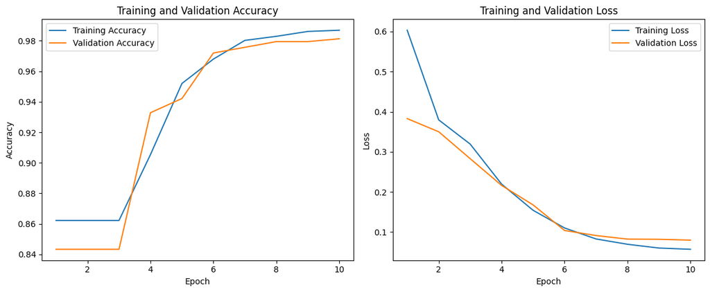

```python
seq_lengths = 100
batch_sizes = 10
embedding_dim = 400
hidden_dims = 256
n_layers_list = 4
epochs = 10

train_accuracy_list, val_accuracy_list, train_loss_list, val_loss_list, test_loss, test_accuracy = main(
    seq_length=seq_length,
    batch_size=batch_size,
    embedding_dim=embedding_dim,
    hidden_dim=hidden_dim,
    n_layers=n_layers,
    epochs=epochs,
    criterion=criterion,
    lr=lr,
    clip=clip,
    seed=seed,
)

plot_results(train_accuracy_list, val_accuracy_list, train_loss_list, val_loss_list)
```